# The international trade and fishery management of spiny dogfish: A social network approach - ScienceDirect

- View **PDF**

## [Ocean & Coastal Management](https://www.sciencedirect.com/journal/ocean-and-coastal-management)

[Volume 80](https://www.sciencedirect.com/journal/ocean-and-coastal-management/vol/80/suppl/C), August 2013, Pages 65-72

# The international trade and fishery management of spiny dogfish: A social network approach

, , ,

https://doi.org/10.1016/j.ocecoaman.2013.04.007[Get rights and content](https://s100.copyright.com/AppDispatchServlet?publisherName=ELS&contentID=S0964569113001051&orderBeanReset=true)

Full text access

## Highlights

- •

  After the US-FMP adoption, US dogfish exports declined while Canadian exports increased.
- •

  New coastal areas were exploited worldwide to supply the EU market demand as US exports declined.
- •

  The NE-Atlantic fishery closure and the dogfish exclusion from CITES lists will affect the conservation of other stocks.
- •

  In light of international trade and regional species conservation status, the US would benefit from the species listing.

## Abstract

The management of the spiny dogfish (*[Squalus acanthias](https://www.sciencedirect.com/topics/agricultural-and-biological-sciences/squalus-acanthias)*) is a matter of international concern, as this species was a candidate for inclusion in lists for trade regulation. The major demand for its meat is from the European Union (EU) market, with the US and Canada as its two major contributors. The US has yet to support a spiny dogfish listing, although the US Atlantic stock is under a fishery management plan (FMP) that proved to be successful in providing a certified [sustainable fishery](https://www.sciencedirect.com/topics/earth-and-planetary-sciences/sustainable-fishery). We employed a cumulative sum technique to compare trade data for frozen spiny dogfish export from US and Canada to the EU in relation to the FMP adoption. We also constructed a social network to visualize changes in the European trade scenario for spiny dogfish after adoption of the FMP and to predict future trade flow potentially affecting the conservation status of regional dogfish stocks in relation to recent management measures introduced in Europe. The social network analysis revealed that the exclusion of spiny dogfish from trade regulation lists eventually will affect the conservation status of dogfish stocks in Africa, [Asia](https://www.sciencedirect.com/topics/earth-and-planetary-sciences/asia), South America, and the Mediterranean and Black Seas. Our results suggest that the species listing would provide an economic benefit for the US Northwest Atlantic fishery, and will eventually foster the conservation status of other regional stocks worldwide and the search for a more sustainable global exploitation of spiny dogfish.

- [Previous article in issue](https://www.sciencedirect.com/science/article/pii/S0964569113000951)
- [Next article in issue](https://www.sciencedirect.com/science/article/pii/S0964569113000926)

## 1. Introduction

The spiny dogfish ([Squalus](https://www.sciencedirect.com/topics/agricultural-and-biological-sciences/squalus) acanthias) is a small demersal shark with a circumboreal distribution. It schools by size and sex between the coastline and the [continental shelf](https://www.sciencedirect.com/topics/agricultural-and-biological-sciences/continental-shelf) (Compagno, 1984), which facilitate exploitation by fisheries operating inside the [Exclusive Economic Zones](https://www.sciencedirect.com/topics/agricultural-and-biological-sciences/exclusive-economic-zone) (EEZ) of coastal nations. The principal populations are in the east and west North Atlantic (including the Mediterranean and Black Seas), east and [west North Pacific](https://www.sciencedirect.com/topics/earth-and-planetary-sciences/north-west-pacific) (including the Sea of Japan), the eastern South Pacific, the Atlantic coast of South America, the Cape coast of [South Africa](https://www.sciencedirect.com/topics/earth-and-planetary-sciences/republic-of-south-africa), and the southern coasts of Australia and New Zealand (Fowler et al., 2004; IUCN, 2006).

Despite its wide distribution, the spiny dogfish is highly vulnerable to fisheries overexploitation due to its life-history characteristics (slow growth rate, late maturity, low fecundity, and long gestation period). In the *red list of threatened species* of the International Union for Conservation of Nature and [Natural Resources](https://www.sciencedirect.com/topics/earth-and-planetary-sciences/natural-resource) (IUCN), spiny dogfish is classified as *Vulnerable* (VU) globally and *Endangered* (EN) in the Mediterranean (IUCN, 2006; Cavanagh and Gibson, 2007). An increased international concern for its conservation status over the last decade leads to attempts to list the species in Appendix II of the Convention of International Trade in [Endangered Species](https://www.sciencedirect.com/topics/agricultural-and-biological-sciences/endangered-species) of [Wild Fauna](https://www.sciencedirect.com/topics/earth-and-planetary-sciences/wild-fauna) and Flora (CITES). The species was proposed for discussion in 2006 (CoP14 Prop.16, 2007) and 2009 (CoP15 Prop.18, 2010), but both proposals did not reach the two-third vote majority for adoption. The aim of CITES is to prevent threat to species caused by international commercial demand, while ensuring their sustainable exploitation, through the inclusion in specific lists (Appendix I, II and III) for trade regulation (CITES, 1973). A species qualifies for listing in Appendix II if the regulation of trade is necessary to avoid the species becoming eligible for inclusion in Appendix I (species threatened with extinction), or if it is required to ensure that the harvest is not reducing the wild population to a level that might threaten its survival (CITES, 1973). An Appendix II listing does not restrict the species trade as long as the exporter country can certify that the export of the species will not be detrimental to its survival (Sky, 2010).

Most CITES members (Parties) agree that the spiny dogfish appears to meet the biological criteria to get listed in Appendix II, but the proposal has yet to receive the required two-third vote majority for listing (TRAFFIC, 2010). Some experts considered the lack of direct support from the US government, despite its strong historical leadership in managing and conserving elasmobranchs and natural resources in general, as one of the main reasons for the failure in listing dogfish so far (Fordham and Dolan, 2004; Fordham, 2009).

The US Atlantic spiny dogfish fishery has been successfully managed after the stock was declared overfished by the National [Marine Fisheries](https://www.sciencedirect.com/topics/earth-and-planetary-sciences/marine-fishery) Service (NMFS) in 1998. This assessment triggered the adoption of a federal (3–200 miles offshore) US fishery management plan (US-FMP, or FMP) for spiny dogfish (MAFMC, 1999), jointly developed by the Mid-Atlantic and New England Regional Fishery Management Councils (MAFMC-NEFMC) under the Magnuson-Stevens Fishery Conservation and Management Act (MSFCMA) provisions. An interstate FMP was developed in 2002 (ASMFC, 2002) by the Atlantic States Marine Fisheries Commission (ASMFC) to manage dogfish in state waters (0–3 miles offshore). To our knowledge, the US-FMP is the only fishery management regulation specifically employed for dogfish worldwide between 1990 and 2010. The Northwest Atlantic stock was declared rebuilt in 2010 by the NMFS, providing evidence of the effectiveness of the FMP adoption for the species (Dell'Apa et al., 2012a).

The international exploitation of spiny dogfish is mainly driven by the European Union (EU) demand for meat (Lack, 2006). In 2001, the US exported 2700 mt (92% of US dogfish reported landings) and Canada exported 1950 mt (23% of Canadian dogfish reported landings) to the EU (58% of EU spiny dogfish meat imports) (Fowler et al., 2004), which suggest that the North American spiny dogfish stocks are the primary source for the EU market. However, the Canadian Pacific spiny dogfish was recently classified as a different taxonomic species, the North Pacific spiny dogfish (*Squalus suckleyi*) (Ebert et al., 2010). In this regard, the Canadian catch in the northwest Atlantic has being historically marginal, comprising 5.4% of the total recorded landings in this coastal area over the last four decades (Wallace et al., 2009).

Despite its overriding role for the international dogfish exploitation, only recently has the EU adopted measures to protect the species, but only for the Northeast Atlantic stock (from the Bay of Biscay to the Barents Sea). The European Commission (EU Commission) enacted the first commercial quotas for this stock in 1998, although limits were based on historical landings rather than scientific evidence. In addition, the EU Commission, under the scientific advice of the International Council for the Exploration of the Sea (ICES), since 2006 repeatedly proposed a zero quota for total allowable catches (TAC) in the North Sea because the stock was considered depleted (ICES, 2006). Despite scientific advice, the Council of the European Community (EU Council) set higher quota limits (Ellis et al., 2009). As for most of the commercially important stocks the level of TACs set by the EU Council is mainly determined by political decisions, due to fisheries ministers aiming at not losing national consensus because of quota reductions (Holden, 1994; Markus, 2009). The EU Council eventually followed the advice of the EU Commission ending fishing for dogfish in the Northeast Atlantic in 2011 (Council Regulation 57/11). This regulation was further amended in 2012 (Council Regulation 43/12).

With the recent closure of the spiny dogfish fishery in the Northeast Atlantic, future market demand for this area will have to be met primarily from imports (FAO, 2009). In turn, this is predicted to modify the international trade scenario, potentially changing the magnitude of spiny dogfish landings in all major countries characterized by a direct fishery on the species. The majority of these countries lack a specific management strategy for spiny dogfish, which enhances the probability for certain local stocks to reach overexploitation levels in the long-term.

Management of the spiny dogfish fishery at local (Party) level should be tuned in regard of this international trade and its predicted changes, which are also dependent on a possible CITES Appendix II listing in the near future. Therefore, an in depth analysis is needed to understand changes in the international trade in the EU in relation with important management regulations for the fishery: specifically the US-FMP, in consideration of the US role as one of the major historical suppliers to the EU market demand. This type of analysis will help predicting alternative scenarios for the international trade in case the spiny dogfish trade should be regulated, and will be useful in identifying countries most likely to increase fishing pressure to supply the EU market demand.

The primary goal of this paper is to analyze the changes in US and Canadian spiny dogfish exports to the EU in relation to the FMP adoption in 1999, in order to assess the consequence of this management regulation for the two major historical contributors to this market. The second goal is to provide a detailed understanding of the EU trade dynamic changes associated with the adoption of the US-FMP for dogfish through construction and analysis of a social network. This social network is used to identify the major historical exporters of spiny dogfish toward the EU, and to model scenario changes for this trade associated with a possible listing in Appendix II for the species. To our knowledge, this was the first attempt to employ social network analysis to investigate trade of important commercial fish and shark species.

## 2. Material and methods

We collected data on EU external trade from the available Eurostat database “EU27 Trade since 1988” (http://epp.eurostat.ec.europa.eu/newxtweb/), which provides annual data on external trade by all 27 countries partners of the EU (EU27). We chose the good under commodity code 03037520: Frozen dogfish of the species “*[Squalus acanthias](https://www.sciencedirect.com/topics/agricultural-and-biological-sciences/squalus-acanthias)*”, and we collected annual quantities (metric tons) of dogfish exported toward EU27 by all world countries reported between 1990 (no available data before this year) and 2010. The advantage of this database is that provides quantities imported by each EU27 country from each exporting country. We excluded from the analysis all countries for which annual quantities of dogfish (imported and/or exported) were less than 1 mt over the study period, which lead us to consider a total of 65 countries (25 EU27 and 40 non-EU27 countries).

Considering the global distribution range of spiny dogfish (IUCN, 2006), the selected countries are representative for the species international exploitation and for its international trade flows toward EU in general. We assume that exports are a reliable proxy for exploitation, and that the market conforms to demand inelasticity over the study period (e.g., constant demand over time) for simplification. We also assume that, particularly for the most important exporting countries, dogfish exported were caught in the same country or adjacent areas.

We analyzed temporal changes in frozen dogfish (Eurostat database) toward EU27 by US and Canada by plotting a cumulative sum (CUSUM) chart of annual exports from these two countries between 1990 and 2010, in order to visualize clear change points in dogfish export over time. Temporal trends in the CUSUM chart were fitted over time by a LOESS curve with tension at 0.05 (Cleveland and Devlin, 1988). The CUSUM is a visual statistical procedure that allows the detection of temporal changes of a persistent process (Hurst, 1950; Woodward and Goldsmith, 1964; Montgomery, 1991). This technique was successfully applied for the analysis of temporal changes in elasmobranch landings in relation to changes in [fishery regulations](https://www.sciencedirect.com/topics/earth-and-planetary-sciences/fishery-regulation) (Dell’Apa et al., 2012b). For a description of this technique and the methodology refer to Kimmel et al. (2012).

The one-mode network does not allow a clear identification of EU27 countries that have an important role as both importers and exporters toward other European countries, thus preventing the characterization of the specific role of each EU27 country within the trade network. To improve results interpretation, we employed a non-metric multi-dimensional scaling (MDS) of the Regular Equivalence (RE) coefficients between countries following the method of Luczkovich et al. (2003).

MDS represents proximities (similarities or dissimilarities) among a given set of entities (countries in this case) in a two dimensional space, with entities closer to each other having more similar roles in the network. We employed the REGE algorithm in the UCINet to calculate RE coefficients among countries. The Regular Equivalence (RE), or Regular Coloration (White and Reitz, 1983), is an equivalence relation in which two nodes are considered equivalent if holding link relationships with corresponding type of nodes (but not necessarily the same one). Applied to this trade network, regularly equivalent countries import spiny dogfish from equivalent countries (but not necessarily the same one) and export spiny dogfish to equivalent countries (but not necessarily the same one). The RE is a method to partition entities based on their similarities within the network, and thus it allowed us the identification of each country's specific role and trade niches within the EU spiny dogfish trade. For a more detailed description of RE we refer to White and Reitz (1983) and Luczkovich et al. (2003). The REGE coefficient matrixes were used as coordinates to plot the MDS of the two networks (pre-FMP and post-FMP) employing the NetDraw, thus obtaining a visualization of country similarities based on the REGE coefficient. To make the network more congruous to the real-world trade based on the available data, a Johnson's hierarchical clustering of the REGE algorithm matrix was performed in the UCINet (Johnson, 1967). All partitions within the Johnson's clustering are equally valid, as they represent different level of resolution rather than alternative theories (Borgatti et al., 1990). To further simplify network interpretation, a series of regressions were performed to measure cluster adequacy following the method by Luczkovich et al. (2003), in which an analysis of variance is performed with cases as pairs of nodes (countries), the REGE coefficient for each pair as the dependent variable, and the independent variable is a dummy variable coded 1 (pair are in the same cluster, more similar) and 0 (pair are in different clusters, less similar). For each network (pre-FMP and post-FMP) the number of partitions presenting the highest eta-square (highest variance explained) was chosen (Luczkovich et al., 2003), providing the most adequate representation of country similarities within the MDS-REGE coefficient network. For each MDS-REGE coefficient network, each node was visually represented by a different shape based on the geographical location and role in the trade of the corresponding country.

## 3. Results

The time-series CUSUM plot evidenced that over the study period (1990–2010) the US and Canadian trends in frozen spiny dogfish export toward EU were almost perfectly inversely mirroring each other (Fig. 1). The plot shows a clear change point for both countries in 1999, the time for the US-FMP adoption. Before 1999, the trend of US exports was steadily increasing, whereas the Canadian exports trend was concurrently decreasing. After the introduction of the FMP, the two trends abruptly reversed, with the Canadian exports trend constantly increasing and the US export trend decreasing. This result conforms to a planned reduction in US-TAC after the FMP adoption.

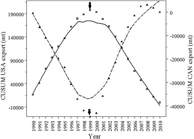

1. [Download: Download full-size image](https://ars.els-cdn.com/content/image/1-s2.0-S0964569113001051-gr1.jpg)

Fig. 1. CUSUM of annual export (mt) of frozen spiny dogfish toward the EU by [USA](https://www.sciencedirect.com/topics/earth-and-planetary-sciences/united-states-of-america) (open squares) and Canada (solid triangles) with relative trend expressed as LOESS (solid line for US and dashed line for Canada) at tension of 0.05. Black arrows indicate the introduction of the federal US-FMP.

The one-mode network for the pre-FMP period (1990–1999) indicates that US was the major exporter toward EU27 countries, with major flow trade toward France, United Kingdom, Ireland, Germany, Belgium, and Netherlands (Fig. 2a). Also, Italy was one of the major importers of frozen dogfish within the EU27, importing smaller quantities from different countries in North America (USA), Central America (Panama and Honduras), South America (Brazil, Argentina, and Uruguay), Africa (from Morocco to South Africa), and [Asia](https://www.sciencedirect.com/topics/earth-and-planetary-sciences/asia) (from Iran to South Korea). Other exporters toward EU27 countries within this period, but with fewer quantities than US, were Canada, Argentina, and New Zealand.

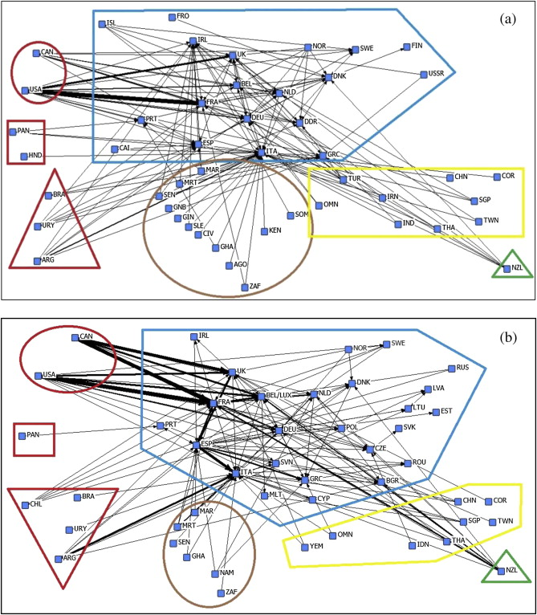

1. [Download: Download full-size image](https://ars.els-cdn.com/content/image/1-s2.0-S0964569113001051-gr2.jpg)

Fig. 2. One-mode network for the pre-FMP period (1990–1999) (a), and for the post-FMP period (2000–2010) (b). Nodes represent countries and edges represent link-relationships between countries based on quantities of dogfish exported, with arrows pointing from the exporter to the importer country. Countries are displayed based on their geographical location: North America (red ellipse), Central America (red rectangle), South America (red triangle), Africa (brown ellipse), [Asia](https://www.sciencedirect.com/topics/earth-and-planetary-sciences/asia) (yellow rectangle in a and yellow polygon in b), Europe (blue polygon), and [Oceania](https://www.sciencedirect.com/topics/earth-and-planetary-sciences/oceania) (green triangle). For a list of country abbreviation see Appendix 1.

The one-mode network for the post-FMP period (2000–2010) shows that, compared to the previous period, US exports to the EU decreased while new countries increased their importance as exporters; particularly Canada, Argentina, and New Zealand. Also, amongst the EU27 countries, Spain became a central importer and exporter toward both other west European countries (e.g. Portugal, Italy, France, and Greece) and several east European countries (e.g. Czech Republic, Poland, Bulgaria, and Slovenia). In addition, new east European countries entered the network, increasing the demand for dogfish, in particular: Poland, Czech Republic, Bulgaria, Romania, Slovakia, Russia, and all Baltic countries from Lithuania to Estonia.

The MDS-REGE plot for the pre-FMP period (Fig. 3a) resulted from a country-type partitioning of the network in 19 different clusters, explaining the highest variance among all the possible partitioning (eta-square = 0.802). This graph indicates that US was the major exporter toward EU27 countries and that it was not similar (regularly equivalent) to any of the other countries. Canada represented its own cluster, as well as Argentina with Mauritania, and New Zealand with Turkey. Within the EU27 countries playing the role of importer-exporter, United Kingdom and France were regularly equivalent, along with Belgium and Germany, and Greece and Netherlands. Italy and Spain were partitioned into two different clusters.

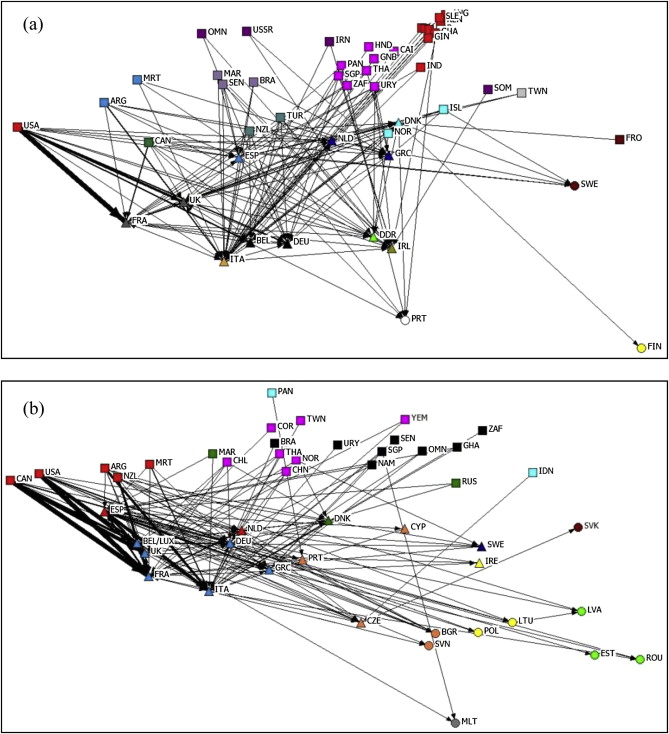

1. [Download: Download full-size image](https://ars.els-cdn.com/content/image/1-s2.0-S0964569113001051-gr3.jpg)

Fig. 3. Non-metric MDS of the REGE coefficient for the pre-FMP period (1990–1999) (a), and for the post-FMP period (2000–2010) (b). Nodes represent countries and edges represent link-relationships between countries based on quantities of dogfish exported, with arrows pointing from the exporter to the importer country. Countries are partitioned (same color) based on the highest eta-square obtained from regression analysis (see text in Material and methods), with 19 partitioning for the pre-FMP period (eta-square = 0.802) and 12 partitioning for the post-FMP period (eta-square = 0.687). In Fig. 3a, USA happens to have the same color (red) of countries located in the higher-right corner due to the shortage of colors available. Therefore, the two clusters are not regularly equivalent. Square nodes indicate non-EU27 exporters; triangle nodes indicate EU27 countries that are both importers and exporters within the EU27 dogfish trade network; circle nodes indicate EU27 countries that are only importers of dogfish. For a list of country abbreviation see Appendix 1.

The MDS-REGE plot of the post-FMP period (Fig. 3b) resulted from a partitioning of the network into 12 different groups based on their RE coefficients (eta-square = 0.687). The plot indicates the presence of a major cluster of exporting countries that in the graph are colored in red. This cluster includes US, Canada, Argentina, Mauritania, and New Zealand as non-EU27 countries (squares), and Spain and Netherlands as EU27 countries (triangles). Among these countries, US and Canada have similar thickness of their link-relationship with other countries. This plot also shows the presence of a second main cluster of regularly equivalent countries within the list of EU27 importer-exporter that in the graph are colored in blue. This cluster includes Belgium, Luxemburg, United Kingdom, France, Germany, Greece, and Italy. The plot also revealed an increase of EU27 importers of frozen dogfish amongst east European countries (e.g. Bulgaria, Romania, Estonia, and Poland) compared to the pre-FMP period, with Czech Republic potentially playing the role of main importer and re-exporter toward some of those countries for future years (i.e. Slovakia).

## 4. Discussion

An important finding is the significant importer-exporter role of Spain in EU after 1999 (Fig. 3b), which suggests increased dogfish exploitation by Spain in the Atlantic and in the Mediterranean Sea over the last decade. The Mediterranean fishery currently lacks any form of management for spiny dogfish, due to the absence of a board charged with scientifically advising the EU Commission on the stock status, such as ICES for the Northeast Atlantic. The current scientific advice on Mediterranean fisheries is considered insufficient with most of the demersal, small pelagic or highly migratory species considered overexploited (FAO, 2005; Markus, 2009). The increasing exploitation of dogfish by Spain could have potentially threatened the conservation status of the Mediterranean stock in the absence of a specific fishery management regulation for dogfish. Concerns exist due to reported relationship between fishing exploitation and the diminishing of [Squalidae](https://www.sciencedirect.com/topics/agricultural-and-biological-sciences/squalidae) in the Mediterranean (Gristina et al., 2006; Dell'Apa et al., 2012b, Dell'Apa et al., 2012a). In 2009, the [Food and Agriculture Organization](https://www.sciencedirect.com/topics/agricultural-and-biological-sciences/food-and-agriculture-organization) of the United Nation Expert Advisory Panel (FAO-EAP) declared that the Mediterranean population is considered to meet the extent of the decline criterion (FAO, 2009).

We also found increasing demand for spiny dogfish from several east European countries (Figs. 2b and 3b), which can represent a trade niche for the future. In 1999 (FMP adoption), these countries (i.e. Romania, Bulgaria, Czech Republic, Poland, Slovenia, Slovakia, Estonia, Lithuania, and Latvia) were not members of the EU. The recent inclusion of these countries, most of which were formerly part of the [Soviet Union](https://www.sciencedirect.com/topics/earth-and-planetary-sciences/u-s-s-r) or under a more directed economic influence from Russia, has widened the international trade of spiny dogfish given its low price (EUR 10–15 kg<sup>-1</sup>, *In* Fowler et al., 2004). Therefore, it is likely that the eastern European market demand can eventually fuel the exploitation of dogfish from other areas that could harm the conservation status of regional and local stocks in case of unmanaged fisheries. Romania and Bulgaria can also exploit the Black Sea spiny dogfish stock, which is not under a EU-TAC management regulation and is listed as *Vulnerable* (VU) in the *red list of threatened species* of the IUCN (Cavanagh and Gibson, 2007). This exploitation can potentially develop an appreciable trade toward other EU27 countries affecting the conservation status of this stock if this fishery was overexploited.

In case of the species insertion in Appendix II, dogfish caught in EU waters would likely be traded within the EU thus limiting the efficacy of trade regulation (for CITES the EU is considered as a single Party), as these trades will not be subjected to CITES trade limitations (FAO, 2009). However, considering the fishing closure in the Northeast Atlantic, this concern may not hold true. In fact, under this restriction the major historical consumers of spiny dogfish in the EU (i.e. the Northeast Atlantic countries) will have to meet their demand exclusively from imports. In case of listing, the US would have an advantage toward other non-EU27 countries (except for Spain) in providing dogfish to the Northeast Atlantic area because of its MSC certification.

Our network results suggest that several African and Asian countries could potentially intensify the species exploitation to supply the EU27 market demand in the future (Fig. 2a), and some countries (e.g. Mauritania) have already been reporting such increase (Figs. 2b and 3b). In addition, several South American countries (e.g. Argentina, Brazil, Uruguay, and Chile) could potentially increase their exploitation if the European demand should increase (Fig. 2b). The conservation status for dogfish stocks in these countries jurisdiction is unknown or data deficient, with a lack of specific stock biomass estimation that could be employed to develop appropriate management measures to promote local fishery sustainability. For example, the export from Argentina increased after the US-FMP introduction (Fig. 2b), but a detailed biomass estimation of the local dogfish stock has yet to be produced (M. Belleggia, pers. comm.).

In contrast, some preliminary information for Squalidae are available for the Southern coasts of Africa, where the shortnose spiny dogfish *[Squalus](https://www.sciencedirect.com/topics/agricultural-and-biological-sciences/squalus)* *megalops* and the shortspine spiny dogfish *Squalus mitsukurii* are found along the eastern Cape coast (Compagno et al., 1989; Smale et al., 1993), while *S. acanthias* occurs on the Cape west coast (Compagno et al., 1991).

Preliminary studies were conducted to investigate the *S. megalops* biology and reproduction (Watson and Smale, 1998), and to examine the species age and growth rate for assessing the potential for fishery exploitation (Watson and Smale, 1999). Authors concluded that, despite recorded high biomass for the species, this population necessitates cautious management approach should it become a target because of the species life-history characteristics (Watson and Smale, 1999). Although *S. acanthias* matures at a similar age to *S. megalops* (McFarlane and Beamish, 1987), it is reported to reach a greater maximum age of at least 70 years (Beamish and McFarlane, 1985), attains greater size and has litters of up to 32 young, although this number varies geographically (Hanchet, 1998). Overall, these biological characteristics can be promising for exploring a potential sustainable exploitation of *S. acanthias* in the western Cape area, and should prompt the need for a detailed population [stock assessment](https://www.sciencedirect.com/topics/earth-and-planetary-sciences/stock-assessment) from South Africa to Namibia. It was already suggested that the deteriorating status of stocks elsewhere and the introduction of catch limits in some fisheries, together with continued strong international demand, may drive development of such a fishery (Lack, 2006).

## 5. Conclusions

The network analysis also indicated that new areas increased exploitations to supply the EU market demand as US exports declined, potentially affecting the conservation status of regional and local spiny dogfish stocks in African, Asian and South American coastal areas. Although there is no directed fishery for spiny dogfish off South Africa, our results, and available information on the species biology and management regulations introduced in the Northeast Atlantic, suggest that the South African-Namibian coastal area may be a potential fishing ground for dogfish in the future. This fishery should be considered for the employment of a management strategy prior to exploitation to ensure the fishery is sustainable and will help preventing the species overexploitation.

Considering both the reported and forecasted increased exploitation of spiny dogfish stocks in the Mediterranean and Black Seas (e.g. Spain, Romania, and Bulgaria), awareness in the conservation status of these spiny dogfish stocks is also needed in order to encourage the introduction of conservation measures in this area, which is under the authority of the EU fishery management but lacking behind in terms of spiny dogfish conservation measures.

Effective and successful management systems are based on finding the best trade-off between contrasting biological, socio-economic, and political objectives. The case for managing the international trade of spiny dogfish shows that a major goal for managers should be to aim at integrating all these different aspects to effectively contributing to the analysis of risks related to global exploitation. This study indicated that the employment of new analytical techniques, such as social network analysis of available trade data, can be useful in the discussion for implementing the fishery management and international biodiversity protection.

## Acknowledgements

We thank Monica Barone and Stefania Vannuccini at FAO for their comments and suggestions in data acquisition. They are absolved nonetheless from responsibility for the final product. We thank Lisa Schiavinato and four anonymous reviewers whose comments helped in improving the quality of the manuscript. We thank Joseph Luczkovich for providing suggestions in data analysis. The Institute for Coastal Science and Policy at East Carolina University provided additional logistic support.

## Appendix A. Supplementary data

The following is the supplementary data related to this article:[Download: Download Word document (17KB)](https://ars.els-cdn.com/content/image/1-s2.0-S0964569113001051-mmc1.docx)

## References

1. ASMFC, 2002

   ASMFC

   Atlantic States Marine Fisheries Commission

   Interstate Fishery Management Plan for Spiny Dogfish, Atlantic States Marine Fisheries Commission, Washington, D.C (2002)

   Fishery Management Report #40

   [Google Scholar](https://scholar.google.com/scholar_lookup?title=Atlantic%20States%20Marine%20Fisheries%20Commission&publication_year=2002&author=ASMFC)
2. Beamish and McFarlane, 1985

   R.J. Beamish, G.A. McFarlane

   Annulus development on the second dorsal spine of the spiny dogfish *(Squalus acanthias)* and its validity for age determination

   Can. J. Fish. Aquat. Sci., 42 (11) (1985), pp. 1799-1805

   [View at publisher](https://doi.org/10.1139/f85-225)[Crossref](https://doi.org/10.1139/f85-225)Google Scholar
3. Borgatti et al., 1990

   S.P. Borgatti, M.G. Everett, P. Shirey

   LS sets, lambda sets, and other cohesive subsets

   Soc. Networks, 12 (1990), pp. 337-357

   [View PDF](https://www.sciencedirect.com/science/article/pii/037887339090014Z/pdf?md5=d5fbcc78461e8cb06cb67eb5b18c029c&pid=1-s2.0-037887339090014Z-main.pdf)[View article](https://www.sciencedirect.com/science/article/pii/037887339090014Z)[View in Scopus](https://www.scopus.com/inward/record.url?eid=2-s2.0-44949290699&partnerID=10&rel=R3.0.0)[Google Scholar](https://scholar.google.com/scholar_lookup?title=LS%20sets%2C%20lambda%20sets%2C%20and%20other%20cohesive%20subsets&publication_year=1990&author=S.P.%20Borgatti&author=M.G.%20Everett&author=P.%20Shirey)
4. Borgatti et al., 2002

   S.P. Borgatti, M.G. Everett, L.C. Freeman

   Ucinet for Windows: Software for Social Network Analysis

   Analytic Technologies, Harvard, MA (2002)

   Google Scholar
5. Borgatti, 2002

   S.P. Borgatti

   Netdraw Network Visualization

   Analytic Technologies, Harvard, MA (2002)

   [Google Scholar](https://scholar.google.com/scholar_lookup?title=Netdraw%20Network%20Visualization&publication_year=2002&author=S.P.%20Borgatti)
6. Cavanagh and Gibson, 2007

   R.D. Cavanagh, C. Gibson

   Overview of the Conservation Status of Cartilaginous Fishes (Chondrichthyans) in the Mediterranean Sea

   IUCN, Spain (2007), p. 42

   Gland: Switzerland and Malaga

   Google Scholar
7. CITES, 1973

   CITES

   Convention on International Trade in Endangered Species of Wild Fauna and Flora

   (1973)

   Text of the Convention, 27 U.N.T.S. 243

   [Google Scholar](https://scholar.google.com/scholar_lookup?title=Convention%20on%20International%20Trade%20in%20Endangered%20Species%20of%20Wild%20Fauna%20and%20Flora&publication_year=1973&author=CITES)
8. Cleveland and Devlin, 1988

   W.S. Cleveland, S. Devlin

   Locally weighted regression: an approach to regression analysis by local fitting

   J. Amer. Stat. Assoc., 83 (1988), pp. 596-610

   [View in Scopus](https://www.scopus.com/inward/record.url?eid=2-s2.0-84947318637&partnerID=10&rel=R3.0.0)Google Scholar
9. Compagno, 1984

   L.J.V. Compagno

   Sharks of the World. An annotated and illustrated catalogue of sharks species known to date. Part 1. Hexanchiformes to Lamniformes

   FAO Fish. Synopsis, 4 (125) (1984), pp. 1-249

   Pt. 1

   Google Scholar
10. Compagno et al., 1989

    L.J.V. Compagno, D.A. Ebert, M.J. Smale

    Guide to the Sharks and Rays of Southern Africa

    Struik, Cape Town (1989)

    [Google Scholar](https://scholar.google.com/scholar_lookup?title=Guide%20to%20the%20Sharks%20and%20Rays%20of%20Southern%20Africa&publication_year=1989&author=L.J.V.%20Compagno&author=D.A.%20Ebert&author=M.J.%20Smale)
11. Compagno et al., 1991

    L.J.V. Compagno, D.A. Ebert, P.D. Cowley

    Distribution of offshore demersal cartilaginous fish (Class Chondrichthyes) off the west coast of southern Africa, with notes on their systematics

    South. Afr. J. Mar. Sci., 11 (1991), pp. 43-139

    [View at publisher](https://doi.org/10.2989/025776191784287664)[Crossref](https://doi.org/10.2989/025776191784287664)[View in Scopus](https://www.scopus.com/inward/record.url?eid=2-s2.0-0002186674&partnerID=10&rel=R3.0.0)Google Scholar
12. CoP14 Prop. 16, 2007

    CoP14 Prop. 16. 2007. Conference of the Parties to the CITES Convention 2007: Proposal 16. Convention on International Trade in Endangered Species of Wild Fauna and Flora. http://www.cites.org/eng/cop/14/prop/E14-P16.pdf (April 2013).

    Google Scholar
13. CoP15 Prop. 18, 2010

    CoP15 Prop. 18. 2010. Conference of the Parties to the CITES Convention 2010: Proposal 18. Convention on International Trade in Endangered Species of Wild Fauna and Flora. http://www.cites.org/eng/cop/15/prop/E15-P18.pdf (April 2013).

    Google Scholar
14. Council Regulation EC N 57, 2011

    Council Regulation (EC) N 57

    2011 on fixing for 2011 the fishing opportunities for certain fish stocks and groups of fish stocks, applicable in EU waters and, for EU vessels, in certain non-EU waters

    Off. J. Eur. Commun., L24 (1) (2011 of 18 January)
15. Council Regulation EC N 43, 2012

    Council Regulation (EC) N 43

    2012 on fixing for 2012 the fishing opportunities available to EU vessels for certain fish stocks and groups of fish stocks which are not subject to international negotiations or agreements

    Off. J. Eur. Commun., L25 (1) (2012 of 17 January)
16. Dell'Apa et al., 2012a

    A. Dell'Apa, L. Schiavinato, R.A. Rulifson

    The Magnuson-Stevens act (1976) and its reauthorizations: failure or success for the implementation of fishery sustainability and management in the US?

    Mar. Pol., 36 (2012), pp. 673-680

    [View PDF](https://www.sciencedirect.com/science/article/pii/S0308597X11001825/pdfft?md5=38eeab680c45dfc9b30287847495d09a&pid=1-s2.0-S0308597X11001825-main.pdf)[View article](https://www.sciencedirect.com/science/article/pii/S0308597X11001825)[View in Scopus](https://www.scopus.com/inward/record.url?eid=2-s2.0-82055169136&partnerID=10&rel=R3.0.0)Google Scholar
17. Dell'Apa et al., 2012b

    A. Dell'Apa, D.G. Kimmel, S. Clò

    Trends of fish and elasmobranch landings in Italy: associated management implications

    ICES J. Mar. Sci., 69 (6) (2012), pp. 1045-1052

    View at publisher

    [Crossref](https://doi.org/10.1093/icesjms/fss067)[View in Scopus](https://www.scopus.com/inward/record.url?eid=2-s2.0-84863590080&partnerID=10&rel=R3.0.0)Google Scholar
18. Ebert et al., 2010

    D.A. Ebert, W.T. White, K.J. Goldman, L.J.V. Compagno, T.S. Daly-Engel, R.D. Ward

    Resurrection and redescription of *Squalus suckleyi* (Girad, 1854) from the North Pacific, with comments on the *Squalus acanthias* subgroup (Squaliformes: Squalidae)

    Zootaxa, 2612 (2010), pp. 22-40

    [View in Scopus](https://www.scopus.com/inward/record.url?eid=2-s2.0-77956653564&partnerID=10&rel=R3.0.0)Google Scholar
19. Ellis et al., 2009

    J. Ellis, S. Doran, G. Dunlin, S. Hetherington, J. Keable, N. Skea

    Fisheries Science Partnership: 2009 Final Report Programme 9: Spurdog in the Irish

    Centre for Environment, Fisheries and Aquaculture Science (CEFAS) (2009)

    [http://www.cefas.co.uk/media/359108/spurdog%20fsp_final%20report_v2.pdf](http://www.cefas.co.uk/media/359108/spurdog%2520fsp_final%2520report_v2.pdf)

    (November 2012)

    Google Scholar
20. FAO, 2005

    FAO

    Food and Agriculture Organization of the United Nations

    Fisheries Laws and Regulations in the Mediterranean: a Comparative Study, General Fisheries Commission for the Mediterranean, Rome (2005)

    [Google Scholar](https://scholar.google.com/scholar_lookup?title=Food%20and%20Agriculture%20Organization%20of%20the%20United%20Nations&publication_year=2005&author=FAO)
21. FAO, 2009

    FAO

    Food and Agriculture Organization of the United Nations

    Report of the Third FAO ad hoc Expert Advisory Panel for the Assessment of Proposals to Amend Appendices I and II of CITES Concerning Commercially-exploited Aquatic Species, FAO, Rome (2009)

    Fisheries Report N° 925, FIMF/R925

    [Google Scholar](https://scholar.google.com/scholar_lookup?title=Food%20and%20Agriculture%20Organization%20of%20the%20United%20Nations&publication_year=2009&author=FAO)
22. Fordham and Dolan, 2004

    S. Fordham, C. Dolan

    A case study in international shark conservation: the convention on international trade in endangered species and the spiny dogfish

    Golden Gate Univ. Law Rev., 34 (3) (2004), pp. 531-572

    Google Scholar
23. Fordham, 2009

    S. Fordham

    Conservation of Atlantic spiny dogfish under U.S. law and CITES

    V.F. Gallucci, G.A. McFarlane, G.G. Bargmann (Eds.), Biology and Management of Dogfish Sharks, American Fisheries Society, Bethesda, Maryland (2009), pp. 411-423

    [Google Scholar](https://scholar.google.com/scholar_lookup?title=Conservation%20of%20Atlantic%20spiny%20dogfish%20under%20U.S.%20law%20and%20CITES&publication_year=2009&author=S.%20Fordham)
24. Fowler et al., 2004

    S. Fowler, C. Raymakers, U. Grimm

    Trade in and Conservation of Two Shark Species, Porbeagle (*Lamna nasus*) and Spiny Dogfish (*Squalus acanthias*)

    CoP13 Inf.16, BFN Skripten 118, Bonn (2004), p. 58

    Google Scholar
25. Gristina et al., 2006

    M. Gristina, T. Bahri, F. Fiorentino, G. Garofalo

    Comparison of demersal fish assemblages in three areas of the Strait of Sicily under different trawling pressure

    Fisher. Res., 81 (2006), pp. 60-71

    [View PDF](https://www.sciencedirect.com/science/article/pii/S0165783606001822/pdfft?md5=3494a2de356ba1fda45518aed7caf168&pid=1-s2.0-S0165783606001822-main.pdf)[View article](https://www.sciencedirect.com/science/article/pii/S0165783606001822)[View in Scopus](https://www.scopus.com/inward/record.url?eid=2-s2.0-33747156619&partnerID=10&rel=R3.0.0)Google Scholar
26. Hanchet, 1998

    S. Hanchet

    Reproductive biology of *Squalus acanthias* from the East Coast, South Island, New Zealand

    New Zealand J. Mar. Fresh. Res., 22 (1998), pp. 537-549

    [Google Scholar](https://scholar.google.com/scholar_lookup?title=Reproductive%20biology%20of%20Squalus%20acanthias%20from%20the%20East%20Coast%2C%20South%20Island%2C%20New%20Zealand&publication_year=1998&author=S.%20Hanchet)
27. Holden, 1994

    M. Holden

    The Common Fisheries Policy

    (1994)

    (Oxford)

    [Google Scholar](https://scholar.google.com/scholar_lookup?title=The%20Common%20Fisheries%20Policy&publication_year=1994&author=M.%20Holden)
28. Hurst, 1950

    H.E. Hurst

    Long-term storage capacity of reservoirs

    Proceed. Amer. Soc. Civil Engin, 76 (1950), pp. 1-30

    [Google Scholar](https://scholar.google.com/scholar_lookup?title=Long-term%20storage%20capacity%20of%20reservoirs&publication_year=1950&author=H.E.%20Hurst)
29. ICES, 2006

    ICES

    International council for the exploration of the sea. Spurdog in the Northeast Atlantic

    Report of the Working Group on Elasmobranch Fishes (WGEF), ICES Advisory Committee on Fisheries Management (2006), pp. 19-76

    ICES CM2006/ACFM 31

    [Google Scholar](https://scholar.google.com/scholar_lookup?title=International%20council%20for%20the%20exploration%20of%20the%20sea.%20Spurdog%20in%20the%20Northeast%20Atlantic&publication_year=2006&author=ICES)
30. IUCN, 2006

    IUCN

    The International Union for Conservation of Nature

    Squalus Acanthias, The IUCN Red List of Threatened Species (2006)

    http://www.iucnredlist.org/apps/redlist/details/39326/0

    (November 2012)

    [Google Scholar](https://scholar.google.com/scholar_lookup?title=The%20International%20Union%20for%20Conservation%20of%20Nature&publication_year=2006&author=IUCN)
31. Johnson, 1967

    S.C. Johnson

    Hierarchical clustering schemes

    Psychometrika, 32 (1967), pp. 241-253

    [View in Scopus](https://www.scopus.com/inward/record.url?eid=2-s2.0-0014129195&partnerID=10&rel=R3.0.0)[Google Scholar](https://scholar.google.com/scholar_lookup?title=Hierarchical%20clustering%20schemes&publication_year=1967&author=S.C.%20Johnson)
32. Kimmel et al., 2012

    D.G. Kimmel, W.R. Boynton, M.R. Roman

    Long-term decline in the calanoid copepod Acartia tonsa in central Chesapeake Bay, USA: an indirect effect of eutrophication?

    Estuar. Coast. Shelf Sci., 101 (2012), pp. 76-85

    [View PDF](https://www.sciencedirect.com/science/article/pii/S027277141200056X/pdfft?md5=02e31455c74660f5e254c5ff3b112480&pid=1-s2.0-S027277141200056X-main.pdf)[View article](https://www.sciencedirect.com/science/article/pii/S027277141200056X)[View in Scopus](https://www.scopus.com/inward/record.url?eid=2-s2.0-84859009843&partnerID=10&rel=R3.0.0)Google Scholar
33. Lack, 2006

    M. Lack

    Conservation of Spiny Dogfish Squalus Acanthias: a Role for CITES?

    TRAFFIC International (2006)

    [Google Scholar](https://scholar.google.com/scholar_lookup?title=Conservation%20of%20Spiny%20Dogfish%20Squalus%20Acanthias%3A%20a%20Role%20for%20CITES&publication_year=2006&author=M.%20Lack)
34. Luczkovich et al., 2003

    J.J. Luczkovich, S.P. Borgatti, J.C. Johnson, M.G. Everett

    Defining and measuring trophic role similarity in food webs using regular equivalence

    J. Theor. Biol., 220 (2003), pp. 303-321

    [View PDF](https://www.sciencedirect.com/science/article/pii/S002251930393147X/pdf?md5=4c8d44be311d5b4dc0236768d89ebf66&pid=1-s2.0-S002251930393147X-main.pdf)[View article](https://www.sciencedirect.com/science/article/pii/S002251930393147X)[View in Scopus](https://www.scopus.com/inward/record.url?eid=2-s2.0-0037271432&partnerID=10&rel=R3.0.0)Google Scholar
35. MAFMC, 1999

    MAFMC

    Mid-Atlantic Fishery Management Council

    Spiny Dogfish Fishery Management Plan, MAFMC, Dover, Delaware (1999)

    [Google Scholar](https://scholar.google.com/scholar_lookup?title=Mid-Atlantic%20Fishery%20Management%20Council&publication_year=1999&author=MAFMC)
36. Markus, 2009

    T. Markus

    European Fisheries Law: From Promotion to Management

    Europa Law Publishing (2009)

    [Google Scholar](https://scholar.google.com/scholar_lookup?title=European%20Fisheries%20Law%3A%20From%20Promotion%20to%20Management&publication_year=2009&author=T.%20Markus)
37. McFarlane and Beamish, 1987

    G.A. McFarlane, R.J. Beamish

    Validation of the dorsal spine method of age determination for spiny dogfish

    R.C. Summerfelt, G.E. Hall (Eds.), Age and Growth of Fish, State University Press, Ames, Iowa (1987), pp. 287-300

    Google Scholar
38. Montgomery, 1991

    D.C. Montgomery

    Introduction to Statistical Quality Control

    (second ed.), John Wiley and Sons, New York (1991)

    [Google Scholar](https://scholar.google.com/scholar_lookup?title=Introduction%20to%20Statistical%20Quality%20Control&publication_year=1991&author=D.C.%20Montgomery)
39. Sky, 2010

    B.M. Sky

    Getting on the list: politics and procedural maneuvering in CITES Appendix I and II decisions for commercially exploited marine and timber species

    Sust. Dev. L. Pol'y., 10 (3) (2010), pp. 35-40

    Google Scholar
40. Smale et al., 1993

    M.J. Smale, B.A. Roel, A. Badenhorst, J.G. Field

    Analysis of the demersal community of fish and cephalopods on the Agulhas Bank, South Africa

    J. Fish. Biol., 43 (1993), pp. 169-191

    [View in Scopus](https://www.scopus.com/inward/record.url?eid=2-s2.0-0027870856&partnerID=10&rel=R3.0.0)Google Scholar
41. TRAFFIC, 2010

    TRAFFIC

    CITES CoP15 Prop 18 Analysis

    Inclusion of Spiny Dogfish Squalus Acanthias in Appendix II (2010)

    Proponent: Sweden, on behalf of the European Community's Member States acting in the interest of the European Community

    http://www.traffic.org/cites-cop-papers

    (April 2013)

    [Google Scholar](https://scholar.google.com/scholar_lookup?title=CITES%20CoP15%20Prop%2018%20Analysis&publication_year=2010&author=TRAFFIC)
42. Wallace et al., 2009

    S.S. Wallace, G.A. McFarlane, S.E. Campana, J.R. King

    Status of spiny dogfish in Atlantic and Pacific Canada

    V.F. Gallucci, G.A. McFarlane, G.G. Bargmann (Eds.), Biology and Management of Dogfish Sharks, American Fisheries Society, Bethesda, Maryland (2009), pp. 313-334

    Google Scholar
43. Watson and Smale, 1998

    G. Watson, M.J. Smale

    Reproductive biology of shortnose spiny dogfish, *Squalus megalops*, from the Agulhas Bank, South Africa

    Mar. Fresh. Res., 49 (1998), pp. 695-703

    [View in Scopus](https://www.scopus.com/inward/record.url?eid=2-s2.0-0032433273&partnerID=10&rel=R3.0.0)Google Scholar
44. Watson and Smale, 1999

    G. Watson, M.J. Smale

    Age and growth of the shortnose spiny dogfish *(Squalus megalops)* from the Agulhas Bank, South Africa

    South. Afr. J. Mar. Sci., 21 (1999), pp. 9-18

    [View at publisher](https://doi.org/10.2989/025776199784126097)[Crossref](https://doi.org/10.2989/025776199784126097)[View in Scopus](https://www.scopus.com/inward/record.url?eid=2-s2.0-0033382781&partnerID=10&rel=R3.0.0)Google Scholar
45. White and Reitz, 1983

    H.C. White, K.P. Reitz

    Graph and semigroup homomorphisms on networks of relations

    Soc. Networks, 5 (1983), pp. 193-235

    [View at publisher](https://doi.org/10.2307/jj.6167285.14)[Crossref](https://doi.org/10.2307/jj.6167285.14)[Google Scholar](https://scholar.google.com/scholar_lookup?title=Graph%20and%20semigroup%20homomorphisms%20on%20networks%20of%20relations&publication_year=1983&author=H.C.%20White&author=K.P.%20Reitz)
46. Woodward and Goldsmith, 1964

    R.H. Woodward, P.L. Goldsmith

    Cumulative Sum Techniques

    ICI Monograph, 3, Oliver and Boyd, Edinburgh (1964)

    [Google Scholar](https://scholar.google.com/scholar_lookup?title=Cumulative%20Sum%20Techniques&publication_year=1964&author=R.H.%20Woodward&author=P.L.%20Goldsmith)

## Cited by (19)

### [Understanding the mechanism of food waste management by using stakeholder analysis and social network model: An industrial ecology perspective](https://www.sciencedirect.com/science/article/pii/S030438001630206X)

- 2016, Ecological Modelling

  Citation Excerpt :

### [Evaluating artisanal fishing of globally threatened sharks and rays in the Bay of Bengal, Bangladesh](https://doi.org/10.1371/journal.pone.0256146)

- 2021, Plos One

### [Social network analysis as a tool for the analysis of the international trade network of aquatic products](https://doi.org/10.1007/s10499-020-00520-5)

- 2020, Aquaculture International

### [Using DNA Barcoding to Investigate Patterns of Species Utilisation in UK Shark Products Reveals Threatened Species on Sale](https://doi.org/10.1038/s41598-018-38270-3)

- 2019, Scientific Reports

### [Elasmobranch bycatch in the Italian Adriatic pelagic trawl fishery](https://doi.org/10.1371/journal.pone.0191647)

- 2018, Plos One

### [Structure and evolution of the global seafood trade network](https://doi.org/10.1088/1748-9326/10/12/125014)

- 2015, Environmental Research Letters

[View all citing articles on Scopus](http://www.scopus.com/scopus/inward/citedby.url?partnerID=10&rel=3.0.0&eid=2-s2.0-84877803314&md5=ad3bc8494e2fa7c7b816b5f52b5db7)

[View Abstract](https://www.sciencedirect.com/science/article/abs/pii/S0964569113001051)

Copyright © 2013 Elsevier Ltd. All rights reserved.

  Tracy Van Holt, …, Stefan Gelcich

- Fisheries Research, Volume 224, 2020, Article 105459

  Jack Silburn, …, Matthew D. Taylor

  Seungjin Ryu, …, Yousin Suh

### Mentions

- Blog Mentions1

### Social Media

- Shares, Likes & Comments2

[View details](https://plu.mx/plum/a/?doi=10.1016%2Fj.ocecoaman.2013.04.007&theme=plum-sciencedirect-theme&hideUsage=true)